# statlog_german_credit_data_v2

```python
from ucimlrepo import fetch_ucirepo
import numpy as np
import pandas as pd
import seaborn as sns
import matplotlib.pyplot as plt
from sklearn.model_selection import train_test_split
from sklearn.tree import DecisionTreeClassifier
from sklearn.neighbors import KNeighborsClassifier
from sklearn.metrics import accuracy_score, precision_score, recall_score, f1_score, roc_curve, make_scorer, roc_auc_score, precision_recall_curve, auc
from sklearn.ensemble import AdaBoostClassifier, GradientBoostingClassifier, RandomForestClassifier
from sklearn.linear_model import LogisticRegression
from itertools import tee
from sklearn.svm import SVC
from sklearn.model_selection import cross_val_score, GridSearchCV
from sklearn.preprocessing import StandardScaler
```

Github repository:  
https://github.com/pgupta7/Supervised_learning_project.git

I have taken the dataset from the UCI machine learning respository, with following website: https://archive.ics.uci.edu/dataset/144/statlog+german+credit+data. The data contains fincancial infromation associated with a thousand clients and labels them as good or bad credit. The purpose of this assignment is to best classify a client, based on his/her financial history, as a good or a bad one. We note that, as mentioned on the above website, it is more imnportant for the bank to classify a bad credit than a good one.

```python
# fetch dataset
credit_data = fetch_ucirepo(id=144)

# data (as pandas dataframes)
X = credit_data.data.features
y = credit_data.data.targets

# metadata
# print(credit_data.metadata)

# variable information
# print(credit_data.variables)
```

The information below is directly taken from the source website. It describes each of the attributes in the data.  
Attribute 1: (qualitative) Status of existing checking account  
A11 : ... < 0 DM  
A12 : 0 <= ... < 200 DM  
A13 : ... >= 200 DM / salary assignments for at least 1 year  
A14 : no checking account

Attribute 2: (numerical) Duration in month

Attribute 3: (qualitative)  
Credit history  
A30 : no credits taken/ all credits paid back duly A31 : all credits at this bank paid back duly A32 : existing credits paid back duly till now A33 : delay in paying off in the past A34 : critical account/ other credits existing (not at this bank)

Attribute 4: (qualitative) Purpose A40 : car (new) A41 : car (used) A42 : furniture/equipment A43 : radio/television A44 : domestic appliances A45 : repairs A46 : education A47 : (vacation - does not exist?) A48 : retraining A49 : business A410 : others

Attribute 5: (numerical) Credit amount

Attibute 6: (qualitative) Savings account/bonds A61 : ... < 100 DM A62 : 100 <= ... < 500 DM A63 : 500 <= ... < 1000 DM A64 : .. >= 1000 DM A65 : unknown/ no savings account

Attribute 7: (qualitative) Present employment since A71 : unemployed A72 : ... < 1 year A73 : 1 <= ... < 4 years  
A74 : 4 <= ... < 7 years A75 : .. >= 7 years

Attribute 8: (numerical) Installment rate in percentage of disposable income

Attribute 9: (qualitative) Personal status and sex A91 : male : divorced/separated A92 : female : divorced/separated/married A93 : male : single A94 : male : married/widowed A95 : female : single

Attribute 10: (qualitative) Other debtors / guarantors A101 : none A102 : co-applicant A103 : guarantor

Attribute 11: (numerical) Present residence since

Attribute 12: (qualitative) Property A121 : real estate A122 : if not A121 : building society savings agreement/ life insurance A123 : if not A121/A122 : car or other, not in attribute 6 A124 : unknown / no property

Attribute 13: (numerical) Age in years

Attribute 14: (qualitative) Other installment plans A141 : bank A142 : stores A143 : none

Attribute 15: (qualitative) Housing A151 : rent A152 : own A153 : for free

Attribute 16: (numerical) Number of existing credits at this bank

Attribute 17: (qualitative) Job A171 : unemployed/ unskilled - non-resident A172 : unskilled - resident A173 : skilled employee / official A174 : management/ self-employed/ highly qualified employee/ officer

Attribute 18: (numerical) Number of people being liable to provide maintenance for

Attribute 19: (qualitative) Telephone A191 : none A192 : yes, registered under the customers name

Attribute 20: (qualitative) foreign worker A201 : yes A202 : no

## Exploratory data analysis

Checking the description of data

```python
X.info()
```

```
<class 'pandas.core.frame.DataFrame'>
RangeIndex: 1000 entries, 0 to 999
Data columns (total 20 columns):
 #   Column       Non-Null Count  Dtype
---  ------       --------------  -----
 0   Attribute1   1000 non-null   object
 1   Attribute2   1000 non-null   int64
 2   Attribute3   1000 non-null   object
 3   Attribute4   1000 non-null   object
 4   Attribute5   1000 non-null   int64
 5   Attribute6   1000 non-null   object
 6   Attribute7   1000 non-null   object
 7   Attribute8   1000 non-null   int64
 8   Attribute9   1000 non-null   object
 9   Attribute10  1000 non-null   object
 10  Attribute11  1000 non-null   int64
 11  Attribute12  1000 non-null   object
 12  Attribute13  1000 non-null   int64
 13  Attribute14  1000 non-null   object
 14  Attribute15  1000 non-null   object
 15  Attribute16  1000 non-null   int64
 16  Attribute17  1000 non-null   object
 17  Attribute18  1000 non-null   int64
 18  Attribute19  1000 non-null   object
 19  Attribute20  1000 non-null   object
dtypes: int64(7), object(13)
memory usage: 156.4+ KB
```

It appears that the data type of many columns is categorical

Checking the description of Continuous columns

```python
X.describe()
```

|  | Attribute2 | Attribute5 | Attribute8 | Attribute11 | Attribute13 | Attribute16 | Attribute18 |
| --- | --- | --- | --- | --- | --- | --- | --- |
| count | 1000.000000 | 1000.000000 | 1000.000000 | 1000.000000 | 1000.000000 | 1000.000000 | 1000.000000 |
| mean | 20.903000 | 3271.258000 | 2.973000 | 2.845000 | 35.546000 | 1.407000 | 1.155000 |
| std | 12.058814 | 2822.736876 | 1.118715 | 1.103718 | 11.375469 | 0.577654 | 0.362086 |
| min | 4.000000 | 250.000000 | 1.000000 | 1.000000 | 19.000000 | 1.000000 | 1.000000 |
| 25% | 12.000000 | 1365.500000 | 2.000000 | 2.000000 | 27.000000 | 1.000000 | 1.000000 |
| 50% | 18.000000 | 2319.500000 | 3.000000 | 3.000000 | 33.000000 | 1.000000 | 1.000000 |
| 75% | 24.000000 | 3972.250000 | 4.000000 | 4.000000 | 42.000000 | 2.000000 | 1.000000 |
| max | 72.000000 | 18424.000000 | 4.000000 | 4.000000 | 75.000000 | 4.000000 | 2.000000 |

It doesn't appear form the description that the dataset has any particularly abnormal values in the continuous columns. Below, I will plot the pairwise plot to further check for any anomalous values.

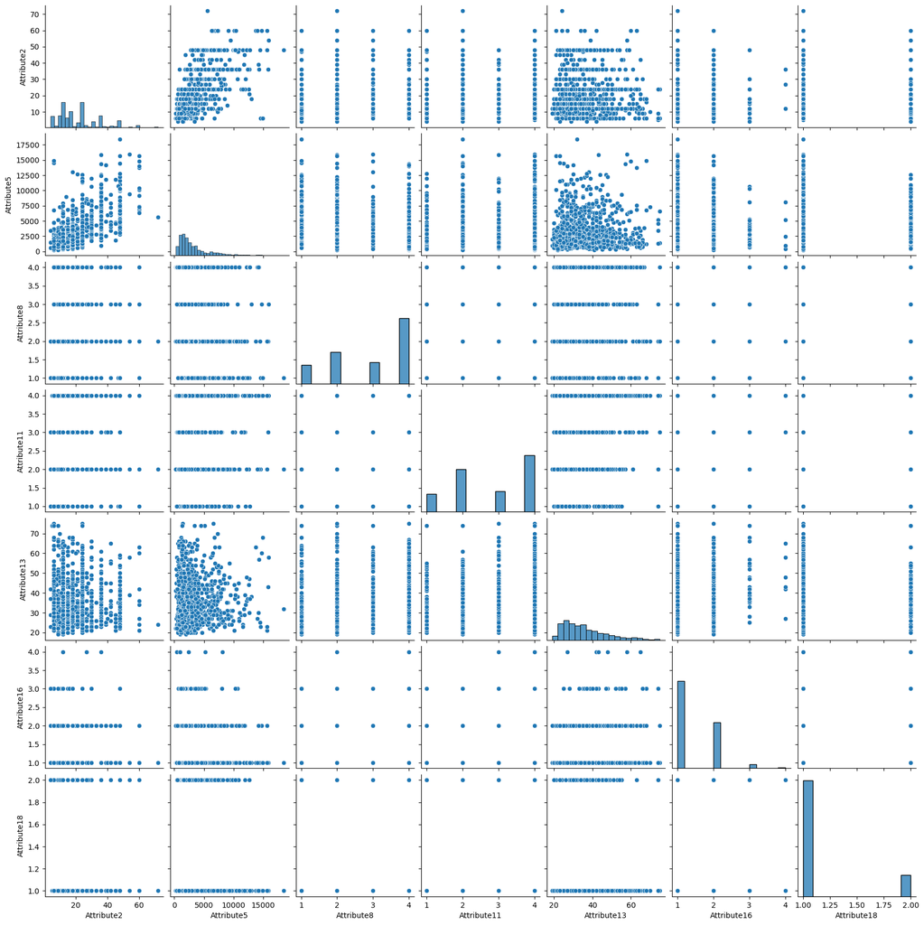

```python
sns.pairplot(X)
```

Attributes 8, 11, 16, and 18 although appear categorical from the above pairwise plots, they are ordinal, as these columns represent Instalment rate in percentage of disposable income, duration of the present residence, number of existing credits at this bank, and the number of people liable to provide maintenance for, respectively. Hence, we can keep them in our classification models as they are.  
For the remaining numeric coulumns, we do not see anything anomalous.

Next, we will check the categorical columns for any anomalies.

```python
X.describe(include=['object', 'category'])
```

|  | Attribute1 | Attribute3 | Attribute4 | Attribute6 | Attribute7 | Attribute9 | Attribute10 | Attribute12 | Attribute14 | Attribute15 | Attribute17 | Attribute19 | Attribute20 |
| --- | --- | --- | --- | --- | --- | --- | --- | --- | --- | --- | --- | --- | --- |
| count | 1000 | 1000 | 1000 | 1000 | 1000 | 1000 | 1000 | 1000 | 1000 | 1000 | 1000 | 1000 | 1000 |
| unique | 4 | 5 | 10 | 5 | 5 | 4 | 3 | 4 | 3 | 3 | 4 | 2 | 2 |
| top | A14 | A32 | A43 | A61 | A73 | A93 | A101 | A123 | A143 | A152 | A173 | A191 | A201 |
| freq | 394 | 530 | 280 | 603 | 339 | 548 | 907 | 332 | 814 | 713 | 630 | 596 | 963 |

Above description of the categorical columns tells us the number of unique values in each of the categorical columns. Next we will check the unique values present in each of the columns.

```python
dum = list(map(lambda c: print(c,':\t', X[c].unique()) if (X[c][0].__class__.__name__ == 'str') else None, X.columns))
```

```
Attribute1 :	 ['A11' 'A12' 'A14' 'A13']
Attribute3 :	 ['A34' 'A32' 'A33' 'A30' 'A31']
Attribute4 :	 ['A43' 'A46' 'A42' 'A40' 'A41' 'A49' 'A44' 'A45' 'A410' 'A48']
Attribute6 :	 ['A65' 'A61' 'A63' 'A64' 'A62']
Attribute7 :	 ['A75' 'A73' 'A74' 'A71' 'A72']
Attribute9 :	 ['A93' 'A92' 'A91' 'A94']
Attribute10 :	 ['A101' 'A103' 'A102']
Attribute12 :	 ['A121' 'A122' 'A124' 'A123']
Attribute14 :	 ['A143' 'A141' 'A142']
Attribute15 :	 ['A152' 'A153' 'A151']
Attribute17 :	 ['A173' 'A172' 'A174' 'A171']
Attribute19 :	 ['A192' 'A191']
Attribute20 :	 ['A201' 'A202']
```

The above section shows the unique values in each of the categorical columns. I attested them against the column description shown at the source link and they match the source description. Besides, since all the unique values match the source description, it tells us there are no anomalous values in these coulumns.

Next, we will check the response data stored in y. Response data is the label against which we check predictions and refine the model.

```python
y.describe()
```

|  | class |
| --- | --- |
| count | 1000.000000 |
| mean | 1.300000 |
| std | 0.458487 |
| min | 1.000000 |
| 25% | 1.000000 |
| 50% | 1.000000 |
| 75% | 2.000000 |
| max | 2.000000 |

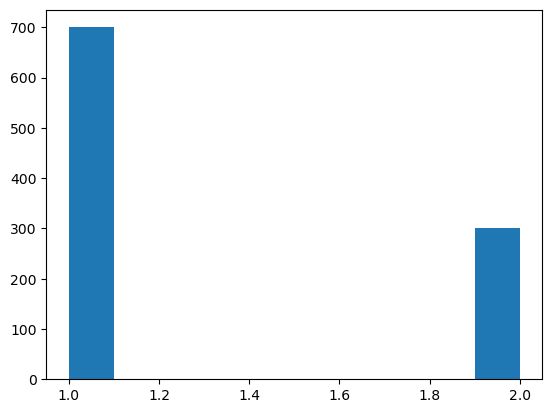

```python
plt.hist(y)
```

We can see that the response data is distributed between 1 and 2, representing good and the bad credit, respectively. We note a few things about the response variable:

- Since there are only two labels, it is a binary classification issue.
- The response is unevenly distributed between 1 and 2, i.e., good and bad risk, which is in the ratio of 70 to 30, respectively. In this case, even if a classifier classifies all the points as 1, i.e., good credit risk, the accuracy will be 0.7, which is not helpful. For the current purpose, we need to be able to classify the bad credit risk as efficiently as possible, which is in the minority. Therefore, we will need other metrics like recall, precision, and f1 scores, instead of accuracy to benchmark our models.

## Preparing data for modeling

```python
# checking the shape of the data
print('shape of the data: ', X.shape)
print('shape of the response data: ', y.shape)
```

```
shape of the data:  (1000, 20)
shape of the response data:  (1000, 1)
```

A few points to note:

- As shown above, the response is distributed between 1 and 2, i.e, good and bad risk However, SkLearn classifiers are designed by default to consider 0 as negative and 1 as positive. So, we will change the response values to this format, i.e., 0 representing a good credit and 1, a bad one.
- To perform classification based on columns with categorical values, we will have to convert them to an appropriate format, where we will create additional columns based on the categories within a column.
- Some of the algorithms that we will use benefit from scaling of the features, viz., Logistic regression, K-Nearest Neighbour, Support vector machines. Other algorithms — Decision-Tree based — are not affected by the standardization, viz., Adaboost, Random Forest, and GradientDescent using Decsion-Trees as respective classifiers. Since standardization does not negatively impact any of the algorithms, we will perform standardization of the feature columns, i.e, X dataset, for all classification models to avoid going back and forth between two different datasets.

In the below section, we perform all the above modifications:

```python
# Flattening the response data
y = np.ravel(y)
# Changing the range of data from {1,2} to {0, 1}, which better suits the bformat of binary classification of sklearn library
y = [val-1 for val in y]

# creating dummy columns from the categories in the categorical columns
X = pd.get_dummies(X, drop_first= True)
```

```python
#Performing the train and test split, with 20% test data.
X_train, X_test, y_train, y_test = train_test_split(X, y, test_size= 0.2, random_state= 0)

# standardizing the feature columns for various Classification models
sc = StandardScaler()
X_train = sc.fit_transform(X_train)
X_test = sc.fit_transform(X_test)
```

## Modeling

Before delving into the modelling, I will discuss my strategy. I will consider multiple supervised learning classification algorithms to classify the data, tuning their hyperparameters to get the best model. The tuning strategy will depend on various metrics, including accuracy, precision, recall, f1 score, and area under the precision-recall curve. Since the dataset is skewed with only 30% of positive labels, i.e., bad credits, and it is more critical to identify bad credits compared to good ones, my primary emphasis will be on recall while also paying due attention to precision, f1 scores, and area under the precision-recall curve. Accuracy will not be a significant concern here — as mentioned earlier, it is very easy to get 70% accuracy by classifying everyone as a good credit risk, but it will fail our cause by incorrectly identifying all the bad risks. Similarly, ROC curve will not be part of our metrics, as it is not an optimal indicator with skewed data, instead we will use the precision-recall curve. Nevertheless, we will check accuracy scores to ensure our model isn’t doing anything funny. Finally, we will compare different models to find the best one(s) for the present purpose.

## Logistic Regression

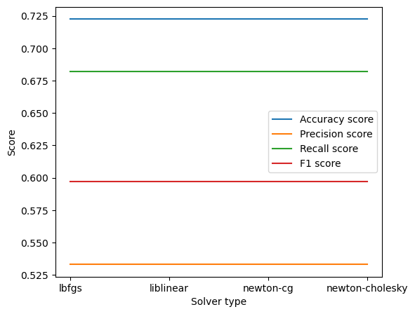

```python
parameters = {'solver': ['lbfgs', 'liblinear', 'newton-cg', 'newton-cholesky']}
# parameters = {'solver': ['lbfgs']}
clf = LogisticRegression(class_weight= 'balanced', C = 1, random_state= 0)
grid_accuracy = GridSearchCV(clf, param_grid= parameters, cv = 5).fit(X_train, y_train)
accuracy_train = grid_accuracy.cv_results_['mean_test_score']
fig, ax = plt.subplots(1,1, figsize = (6, 5))
ax.plot(parameters['solver'], accuracy_train, label = 'Accuracy score')

grid_precision = GridSearchCV(clf, param_grid= parameters, cv = 5, scoring = 'precision').fit(X_train, y_train)
precision_train = grid_precision.cv_results_['mean_test_score']
ax.plot(parameters['solver'], precision_train, label ='Precision score')

grid_recall = GridSearchCV(clf, param_grid= parameters, cv = 5, scoring = 'recall').fit(X_train, y_train)
recall_train = grid_recall.cv_results_['mean_test_score']
ax.plot(parameters['solver'], recall_train, label = 'Recall score')

grid_f1 = GridSearchCV(clf, param_grid= parameters, cv = 5, scoring = 'f1').fit(X_train, y_train)
f1_train = grid_f1.cv_results_['mean_test_score']
ax.plot(parameters['solver'], f1_train, label ='F1 score')
ax.legend()
ax.set_ylabel('Score')
ax.set_xlabel('Solver type')
```

Above, I have studied how the Logistic regression performs using various available solvers. All the solvers perform almost similarly, giving nearly identical results with a cross-validation of 5 sets on the training data. Below, I provide the scores on the test dataset using 'lbfgs' dataset. Besides, I also plot a precision-recall curve, also showing the are under the curve.

```
'Accuracy: 0.705'
```

```
'Precision: 0.494'
```

```
'Recall: 0.672'
```

```
'F1 score: 0.569'
```

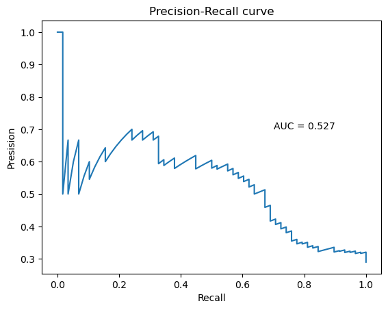

```python
clf_log = LogisticRegression(class_weight= 'balanced', solver = 'lbfgs', random_state= 0).fit(X_train, y_train)
y_pred = clf_log.predict(X_test)
display('Accuracy: '+ str(round(accuracy_score(y_test, y_pred), 3)))
display('Precision: '+ str(round(precision_score(y_test, y_pred), 3)))
display('Recall: '+ str(round(recall_score(y_test, y_pred), 3)))
display('F1 score: '+ str(round(f1_score(y_test, y_pred), 3)))

y_scores = clf_log.predict_proba(X_test)[:, 1]
precision, recall, th = precision_recall_curve(y_test,y_scores)
auc_score = auc(recall, precision)
plt.plot(recall, precision)
plt.text(0.7, 0.7, 'AUC = ' + str(round(auc_score, 3)))
plt.xlabel('Recall')
plt.ylabel('Presision')
plt.title('Precision-Recall curve')
```

## Nearest Neighbor

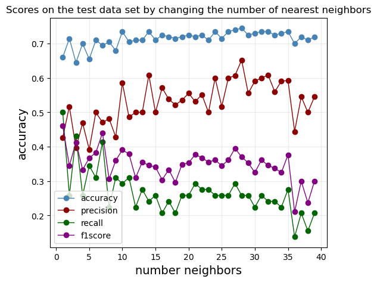

```python
allks = range(1,40)
def computeknn(k):
    knn = KNeighborsClassifier(n_neighbors= k).fit(X_train, y_train)
    y_pred = knn.predict(X_test)
    return accuracy_score(y_test, y_pred), precision_score(y_test, y_pred), recall_score(y_test, y_pred), \
    f1_score(np.ravel(y_test), y_pred)

scores = [computeknn(k) for k in allks]

def extract_scores(n, scores = scores):
    return list(map(lambda x: x[n], scores))

accuracy = extract_scores(0)
precision = extract_scores(1)
recall = extract_scores(2)
f1score = extract_scores(3)

fig, ax = plt.subplots(nrows=1,ncols=1,figsize=(6,5))
ax.plot(allks, accuracy, marker="o", color="steelblue", lw=1, label="accuracy")
ax.plot(allks, precision, marker="o", color="darkred", lw=1, label="precision")
ax.plot(allks, recall, marker="o", color="darkgreen", lw=1, label="recall")
ax.plot(allks, f1score, marker="o", color="purple", lw=1, label="f1score")
ax.set_xlabel("number neighbors", fontsize=14)
ax.set_ylabel("accuracy", fontsize=14)
ax.grid(alpha=0.25)
ax.set_title('Scores on the test data set by changing the number of nearest neighbors')
ax.legend()
```

```
'Accuracy: 0.695'
```

```
'Precision: 0.471'
```

```
'Recall: 0.414'
```

```
'F1 score: 0.44'
```

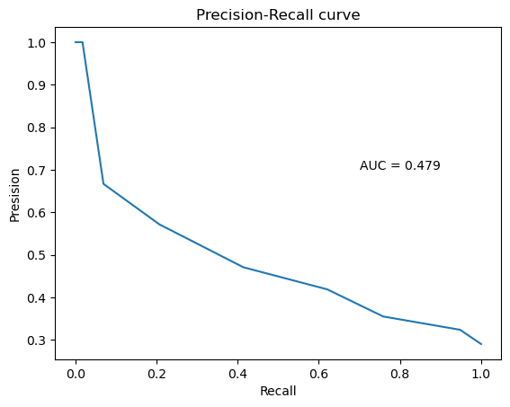

```python
knn = KNeighborsClassifier(n_neighbors= 7).fit(X_train, y_train)
y_pred = knn.predict(X_test)
display('Accuracy: '+ str(round(accuracy_score(y_test, y_pred), 3)))
display('Precision: '+ str(round(precision_score(y_test, y_pred), 3)))
display('Recall: '+ str(round(recall_score(y_test, y_pred), 3)))
display('F1 score: '+ str(round(f1_score(y_test, y_pred), 3)))

y_scores = knn.predict_proba(X_test)[:, 1]
precision, recall, th = precision_recall_curve(y_test,y_scores)
auc_score = auc(recall, precision)
plt.plot(recall, precision)
plt.text(0.7, 0.7, 'AUC = ' + str(round(auc_score, 3)))
plt.xlabel('Recall')
plt.ylabel('Presision')
plt.title('Precision-Recall curve')
```

## Decision Tree Classifier

```python
clf_Dectree = DecisionTreeClassifier(random_state= 0)
path = clf_Dectree.cost_complexity_pruning_path(X_train, y_train)
ccp_alphas, impurities = path.ccp_alphas, path.impurities
```

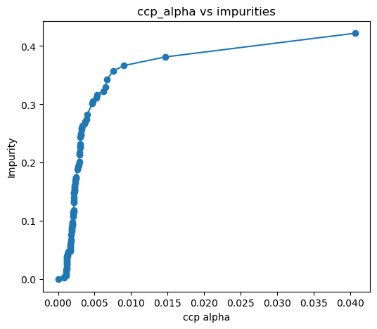

```python
fig, ax = plt.subplots(1,1,figsize = (6,5))
ax.plot(ccp_alphas, impurities, marker = 'o')
ax.set_title('ccp_alpha vs impurities')
ax.set_xlabel('ccp alpha')
ax.set_ylabel('Impurity')
```

The above plot shows the impurity in the tree as a funciton of the cost complexity parameter, ccp alpha values. Next, we will prune the tree based on the cost complexity, the ccp alpha values.

```python
def gettree(ccp_alpha):
    return DecisionTreeClassifier(ccp_alpha = ccp_alpha, random_state= 0).fit(X_train, y_train)

clfs = list(map(gettree, ccp_alphas))
test_scores = list(map(lambda clf: clf.score(X_test, y_test), clfs))
train_scores = list(map(lambda clf: clf.score(X_train, y_train), clfs))
```

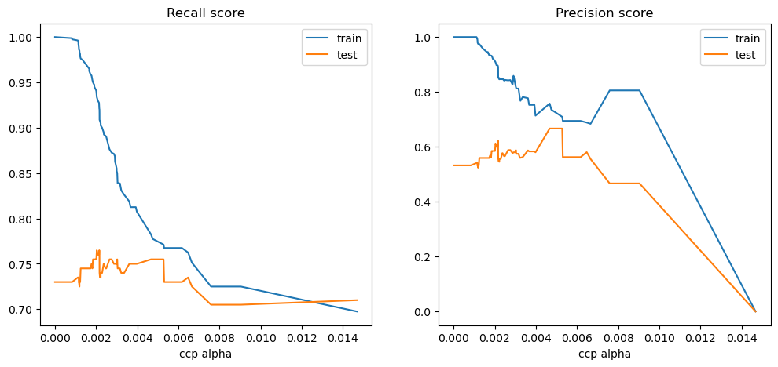

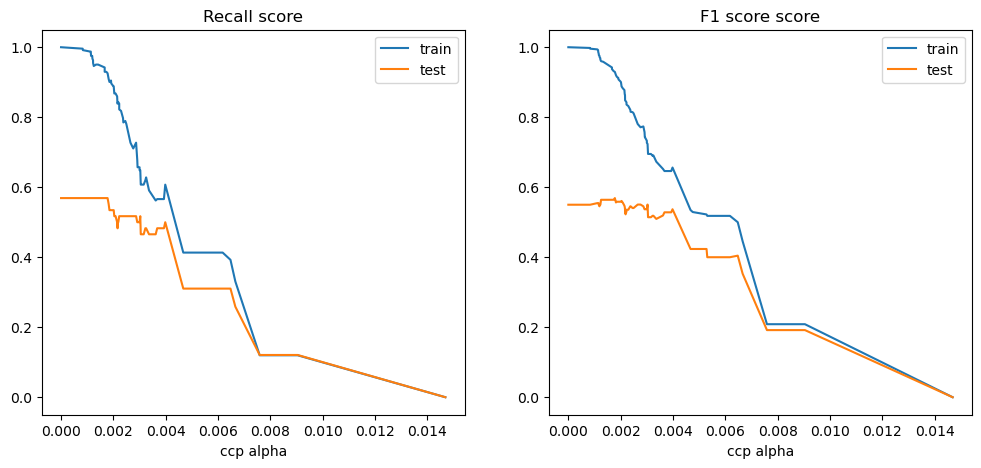

```python
y_pred_train = list(map(lambda clf: clf.predict(X_train), clfs))
y_pred_test = list(map(lambda clf: clf.predict(X_test), clfs))

# computing accuracy score
accuracy_train = list(map(lambda y: accuracy_score(y_train, y), y_pred_train))
accuracy_test = list(map(lambda y: accuracy_score(y_test, y), y_pred_test))

# computing precision score
precision_train = list(map(lambda y: precision_score(y_train, y), y_pred_train))
precision_test = list(map(lambda y: precision_score(y_test, y), y_pred_test))

# computing recall
recall_train = list(map(lambda y: recall_score(y_train, y), y_pred_train))
recall_test = list(map(lambda y: recall_score(y_test, y), y_pred_test))

# computing F1 score
f1_train = list(map(lambda y: f1_score(y_train, y), y_pred_train))
f1_test = list(map(lambda y: f1_score(y_test, y), y_pred_test))

fig, ax = plt.subplots(1,2, figsize = (12, 5))
ax[0].plot(ccp_alphas[:-1], accuracy_train[:-1], label = 'train')
ax[0].plot(ccp_alphas[:-1], accuracy_test[:-1], label = 'test')
ax[0].legend()
ax[0].set_title('Recall score')
ax[0].set_xlabel('ccp alpha')

ax[1].plot(ccp_alphas[:-1], precision_train[:-1], label = 'train')
ax[1].plot(ccp_alphas[:-1], precision_test[:-1], label = 'test')
ax[1].legend()
ax[1].set_title('Precision score')
ax[1].set_xlabel('ccp alpha')

fig, ax = plt.subplots(1,2, figsize = (12, 5))
ax[0].plot(ccp_alphas[:-1], recall_train[:-1], label = 'train')
ax[0].plot(ccp_alphas[:-1], recall_test[:-1], label = 'test')
ax[0].legend()
ax[0].set_title('Recall score')
ax[0].set_xlabel('ccp alpha')

ax[1].plot(ccp_alphas[:-1], f1_train[:-1], label = 'train')
ax[1].plot(ccp_alphas[:-1], f1_test[:-1], label = 'test')
ax[1].legend()
ax[1].set_title('F1 score score')
ax[1].set_xlabel('ccp alpha')
```

```
'Accuracy: 0.75'
```

```
'Precision: 0.58'
```

```
'Recall: 0.5'
```

```
'F1 score: 0.537'
```

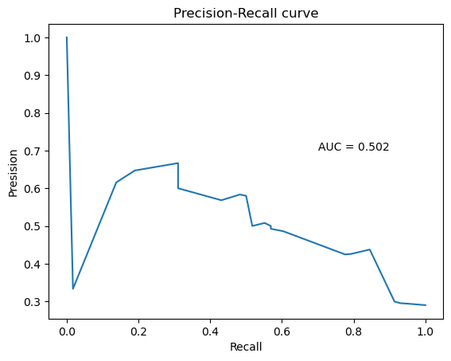

```python
clf = DecisionTreeClassifier(ccp_alpha = 0.003, random_state= 0).fit(X_train, y_train)
y_pred = clf.predict(X_test)

display('Accuracy: '+ str(round(accuracy_score(y_test, y_pred), 3)))
display('Precision: '+ str(round(precision_score(y_test, y_pred), 3)))
display('Recall: '+ str(round(recall_score(y_test, y_pred), 3)))
display('F1 score: '+ str(round(f1_score(y_test, y_pred), 3)))

y_scores = clf.predict_proba(X_test)[:, 1]
precision, recall, th = precision_recall_curve(y_test,y_scores)
auc_score = auc(recall, precision)
plt.plot(recall, precision)
plt.text(0.7, 0.7, 'AUC = ' + str(round(auc_score, 3)))
plt.xlabel('Recall')
plt.ylabel('Presision')
plt.title('Precision-Recall curve')
```

## Performing Adaboost Classification

```python
est = DecisionTreeClassifier(max_depth= 3, random_state= 0)
clf_ada = AdaBoostClassifier(estimator= est, random_state= 0, n_estimators= 70).fit(X_train, y_train)
```

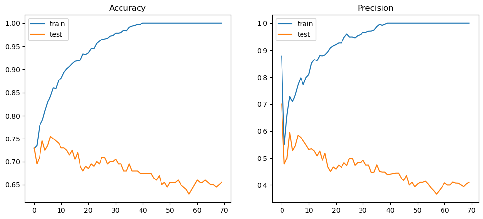

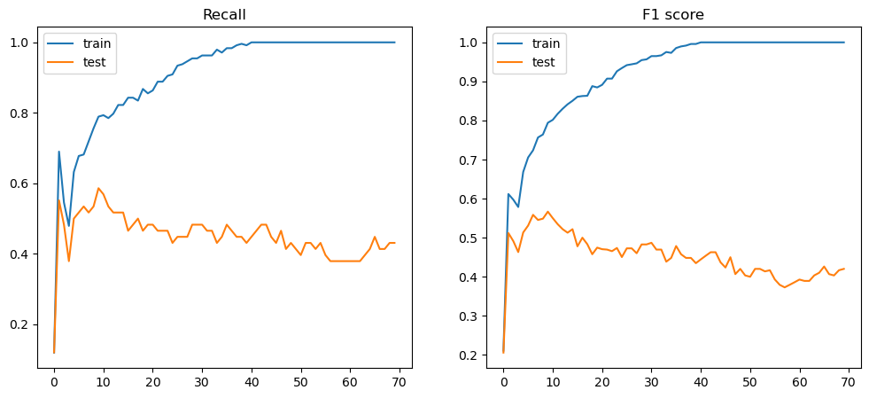

```python
staged_score_train = list(clf_ada.staged_score(X_train, y_train))
staged_score_test = list(clf_ada.staged_score(X_test, y_test))
fig, ax = plt.subplots(1,2, figsize = (12, 5))
ax[0].plot(staged_score_train, label = 'train')
ax[0].plot(staged_score_test, label = 'test')
ax[0].legend()
ax[0].set_title('Accuracy')


staged_predict_train = list(clf_ada.staged_predict(X_train))
staged_predict_test = list(clf_ada.staged_predict(X_test))
staged_precision_train = list(map(lambda y: precision_score(y_train, y), staged_predict_train))
staged_precision_test = list(map(lambda y: precision_score(y_test, y), staged_predict_test))
# display(staged_precision_train)

ax[1].plot(staged_precision_train, label = 'train')
ax[1].plot(staged_precision_test, label = 'test')
ax[1].legend()
ax[1].set_title('Precision')

staged_recall_train = list(map(lambda y: recall_score(y_train, y), staged_predict_train))
staged_recall_test = list(map(lambda y: recall_score(y_test, y), staged_predict_test))

fig, ax = plt.subplots(1,2, figsize = (12, 5))
ax[0].plot(staged_recall_train, label = 'train')
ax[0].plot(staged_recall_test, label = 'test')
ax[0].legend()
ax[0].set_title('Recall')

staged_f1_train = list(map(lambda y: f1_score(y_train, y), staged_predict_train))
staged_f1_test = list(map(lambda y: f1_score(y_test, y), staged_predict_test))

ax[1].plot(staged_f1_train, label = 'train')
ax[1].plot(staged_f1_test, label = 'test')
ax[1].legend()
ax[1].set_title('F1 score')
```

The above plots show the behavior of Adaboost algorithm on the dataset as we increase the number of stump trees. Although the scores on the train dataset saturate to 1 soon, implying overfitting, the test set scores start declining as the number of stump trees go beyond 10. So, we choose the best Adaboost classifier with n_estimator = 10 and calculate the various scores on the test dataset below.

```
'Accuracy: 0.74'
```

```
'Precision: 0.548'
```

```
'Recall: 0.586'
```

```
'F1 score: 0.567'
```

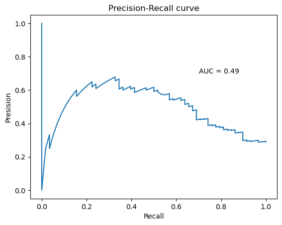

```python
est = DecisionTreeClassifier(max_depth= 3, random_state= 0)
clf_ada = AdaBoostClassifier(estimator= est, random_state= 0, n_estimators= 10).fit(X_train, y_train)

y_pred = clf_ada.predict(X_test)
display('Accuracy: '+ str(round(accuracy_score(y_test, y_pred), 3)))
display('Precision: '+ str(round(precision_score(y_test, y_pred), 3)))
display('Recall: '+ str(round(recall_score(y_test, y_pred), 3)))
display('F1 score: '+ str(round(f1_score(y_test, y_pred), 3)))

y_scores = clf_ada.predict_proba(X_test)[:, 1]
precision, recall, th = precision_recall_curve(y_test,y_scores)
auc_score = auc(recall, precision)
plt.plot(recall, precision)
plt.text(0.7, 0.7, 'AUC = ' + str(round(auc_score, 3)))
plt.xlabel('Recall')
plt.ylabel('Presision')
plt.title('Precision-Recall curve')
```

## Performing Random Forrest

```python
def getpredict(ntrees):
    clf = RandomForestClassifier(n_estimators= ntrees, random_state= 0).fit(X_train, y_train)
    y_pred_train = clf.predict(X_train)
    y_pred_test = clf.predict(X_test)
    return clf.score(X_train, y_train), clf.score(X_test, y_test), precision_score(y_train, y_pred_train),\
    precision_score(y_test, y_pred_test), recall_score(y_train, y_pred_train), recall_score(y_test, y_pred_test),\
    f1_score(y_train, y_pred_train), f1_score(y_test, y_pred_test)

scores = list(map(getpredict, range(1, 100)))

accuracy_train, accuracy_test, precision_train, precision_test, recall_train, recall_test, f1_train, f1_test = zip(*scores)
```

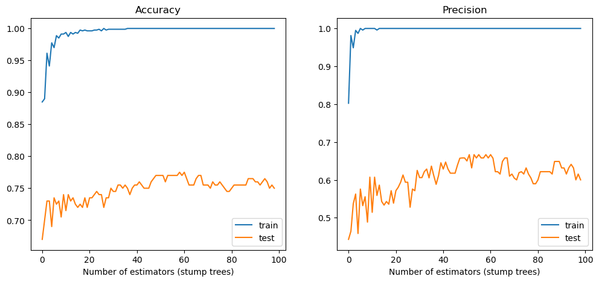

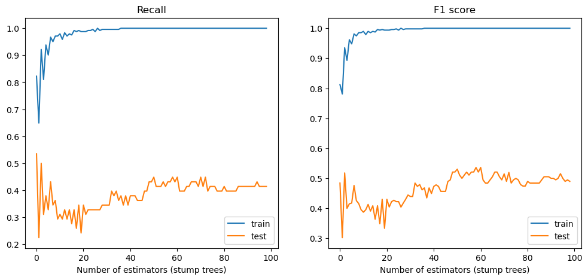

```python
fig, ax = plt.subplots(1,2,figsize = (12,5))
ax[0].plot(accuracy_train, label = 'train')
ax[0].plot(accuracy_test, label = 'test')
ax[0].legend()
ax[0].set_title('Accuracy')
ax[0].set_xlabel('Number of estimators (stump trees)')

ax[1].plot(precision_train, label = 'train')
ax[1].plot(precision_test, label = 'test')
ax[1].legend()
ax[1].set_title('Precision')
ax[1].set_xlabel('Number of estimators (stump trees)')

fig, ax = plt.subplots(1,2,figsize = (12,5))
ax[0].plot(recall_train, label = 'train')
ax[0].plot(recall_test, label = 'test')
ax[0].legend()
ax[0].set_title('Recall')
ax[0].set_xlabel('Number of estimators (stump trees)')

ax[1].plot(f1_train, label = 'train')
ax[1].plot(f1_test, label = 'test')
ax[1].legend()
ax[1].set_title('F1 score')
ax[1].set_xlabel('Number of estimators (stump trees)')
```

The above plots show the behavior of the RandomForest algorithm of the dataset, as we increase the number of estimators. Although the scores on the train dataset saturate to 1 soon, implying overfitting, the test set scores are somewhat noisy. However, the trendlines of the metrics on the test dataset achieve maxima and then either stay there or decline with increase in the number of estimators — A value of 55 for n_estimators seems to work well.  
Below, we show the metrics from the test data computed using the best found Random forest estimator algorithm.

```
'Accuracy: 0.77'
```

```
'Precision: 0.658'
```

```
'Recall: 0.431'
```

```
'F1 score: 0.521'
```

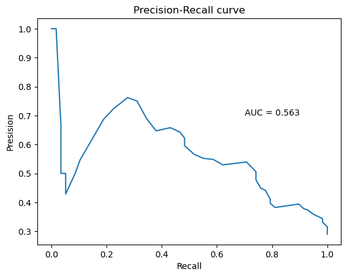

```python
clf = RandomForestClassifier(n_estimators= 55, random_state= 0).fit(X_train, y_train)
y_pred = clf.predict(X_test)
display('Accuracy: '+ str(round(accuracy_score(y_test, y_pred), 3)))
display('Precision: '+ str(round(precision_score(y_test, y_pred), 3)))
display('Recall: '+ str(round(recall_score(y_test, y_pred), 3)))
display('F1 score: '+ str(round(f1_score(y_test, y_pred), 3)))

y_scores = clf.predict_proba(X_test)[:, 1]
precision, recall, th = precision_recall_curve(y_test,y_scores)
auc_score = auc(recall, precision)
plt.plot(recall, precision)
plt.text(0.7, 0.7, 'AUC = ' + str(round(auc_score, 3)))
plt.xlabel('Recall')
plt.ylabel('Presision')
plt.title('Precision-Recall curve')
```

## Gradient boosting algorithm

```python
clf_gd = GradientBoostingClassifier(random_state= 0, n_estimators= 150, learning_rate= 0.25, max_depth= 3).fit(X_train, y_train)
y_pred_train = list(clf_gd.staged_predict(X_train))
y_pred_test = list(clf_gd.staged_predict(X_test))
```

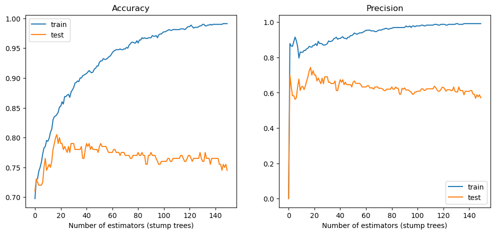

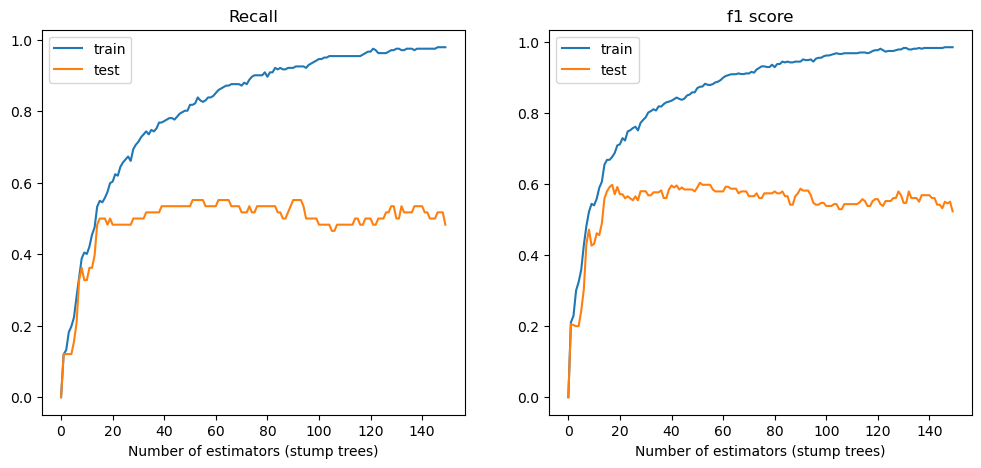

```python
accuracy_train = list(map(lambda y: accuracy_score(y_train, y), y_pred_train))
accuracy_test = list(map(lambda y: accuracy_score(y_test, y), y_pred_test))
fig, ax = plt.subplots(1,2, figsize = (12, 5))
ax[0].plot(accuracy_train, label = 'train')
ax[0].plot(accuracy_test, label = 'test')
ax[0].set_title('Accuracy')
ax[0].legend()
ax[0].set_xlabel('Number of estimators (stump trees)')

precision_train = list(map(lambda y: precision_score(y_train, y), y_pred_train))
precision_test = list(map(lambda y: precision_score(y_test, y), y_pred_test))
ax[1].plot(precision_train, label = 'train')
ax[1].plot(precision_test, label = 'test')
ax[1].set_title('Precision')
ax[1].legend()
ax[1].set_xlabel('Number of estimators (stump trees)')

recall_train = list(map(lambda y: recall_score(y_train, y), y_pred_train))
recall_test = list(map(lambda y: recall_score(y_test, y), y_pred_test))
fig, ax = plt.subplots(1,2, figsize = (12, 5))
ax[0].plot(recall_train, label = 'train')
ax[0].plot(recall_test, label = 'test')
ax[0].set_title('Recall')
ax[0].legend()
ax[0].set_xlabel('Number of estimators (stump trees)')

f1_train = list(map(lambda y: f1_score(y_train, y), y_pred_train))
f1_test = list(map(lambda y: f1_score(y_test, y), y_pred_test))
ax[1].plot(f1_train, label = 'train')
ax[1].plot(f1_test, label = 'test')
ax[1].set_title('f1 score')
ax[1].legend()
ax[1].set_xlabel('Number of estimators (stump trees)')
```

The above plots show the behavior of the Gradient Search algorithm on the dataset, as we increase the number of estimators. Although the scores on the train dataset saturate to 1 soon, implying overfit, the test set scores seem to achieve a acheieve a maximum and then either stay there or appear to decline with increase in the number of estimators. So, we choose the best Gradient Search classifier with n_estimator = 45 and calculate the various scores on the dataset below.

```
'Accuracy: 0.785'
```

```
'Precision: 0.66'
```

```
'Recall: 0.534'
```

```
'F1 score: 0.59'
```

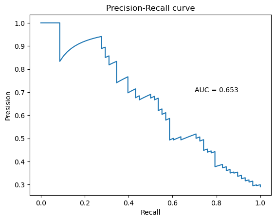

```python
clf_gd = GradientBoostingClassifier(random_state= 0, n_estimators= 45, learning_rate= 0.25, max_depth= 3).fit(X_train, y_train)
y_pred = clf_gd.predict(X_test)
display('Accuracy: '+ str(round(accuracy_score(y_test, y_pred), 3)))
display('Precision: '+ str(round(precision_score(y_test, y_pred), 3)))
display('Recall: '+ str(round(recall_score(y_test, y_pred), 3)))
display('F1 score: '+ str(round(f1_score(y_test, y_pred), 3)))

y_scores = clf_gd.predict_proba(X_test)[:, 1]
precision, recall, th = precision_recall_curve(y_test,y_scores)
auc_score = auc(recall, precision)
plt.plot(recall, precision)
plt.text(0.7, 0.7, 'AUC = ' + str(round(auc_score, 3)))
plt.xlabel('Recall')
plt.ylabel('Presision')
plt.title('Precision-Recall curve')
```

## Support Vector Machine

### Using the Linear kernel

```python
nlsvm = SVC(kernel='linear', probability= True, random_state= 0).fit(X_train, y_train)
parameters = {'C': list(2.0**np.arange(-8, 2, 1))}
grid_accuracy = GridSearchCV(nlsvm, param_grid= parameters, cv = 3).fit(X_train, y_train)
grid_recall = GridSearchCV(nlsvm, param_grid= parameters, cv = 3, scoring= 'recall').fit(X_train, y_train)
grid_precision = GridSearchCV(nlsvm, param_grid= parameters, cv = 3, scoring= 'precision').fit(X_train, y_train)
grid_f1 = GridSearchCV(nlsvm, param_grid= parameters, cv = 3, scoring= 'f1').fit(X_train, y_train)
```

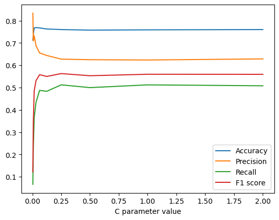

```python
accuracy = grid_accuracy.cv_results_['mean_test_score']
recall = grid_recall.cv_results_['mean_test_score']
precision = grid_precision.cv_results_['mean_test_score']
f1 = grid_f1.cv_results_['mean_test_score']
plt.plot(parameters['C'], accuracy, label = 'Accuracy')
plt.plot(parameters['C'], precision, label = 'Precision')
plt.plot(parameters['C'], recall, label = 'Recall')
plt.plot(parameters['C'], f1, label = 'F1 score')
plt.xlabel('C parameter value')
plt.legend()
```

```python
# computing the C value at which the recall is maximum
ind = np.argmax(recall)
print('best recall at: C =', grid_recall.param_grid["C"][ind])
```

```
best recall at: C = 0.25
```

Above, I perform a cross-validated grid search on the training data using a support vector machine algorith. We see that Recall and F1 score both reach a maximum at C value of 0.25. Although we see precision to be quite high near very small values of C, Recall and F1 scores are very low there, so, I have decided to use C = 0.25 as the optimum one, where recall and the F1 score achieve their maximum.

```
'Accuracy: 0.73'
```

```
'Precision: 0.538'
```

```
'Recall: 0.483'
```

```
'F1 score: 0.509'
```

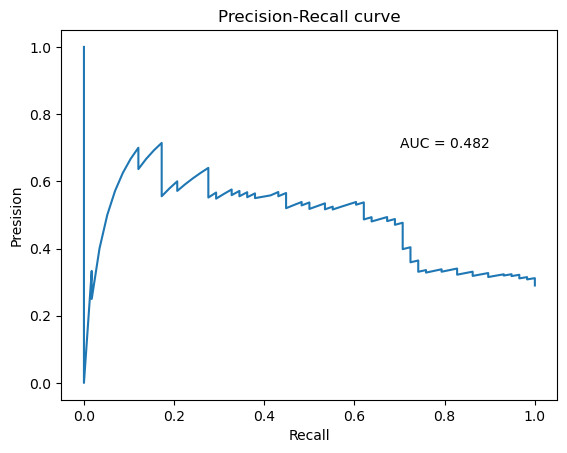

```python
nlsvm = SVC(kernel='linear', C = 0.25, probability= True, random_state= 0).fit(X_train, y_train)
y_pred = nlsvm.predict(X_test)
display('Accuracy: '+ str(round(accuracy_score(y_test, y_pred), 3)))
display('Precision: '+ str(round(precision_score(y_test, y_pred), 3)))
display('Recall: '+ str(round(recall_score(y_test, y_pred), 3)))
display('F1 score: '+ str(round(f1_score(y_test, y_pred), 3)))

y_scores = nlsvm.predict_proba(X_test)[:, 1]
precision, recall, th = precision_recall_curve(y_test,y_scores)
auc_score = auc(recall, precision)

plt.plot(recall, precision)
plt.text(0.7, 0.7, 'AUC = ' + str(round(auc_score, 3)))
plt.xlabel('Recall')
plt.ylabel('Presision')
plt.title('Precision-Recall curve')
```

The above cell shows the various metrics on the test data while using the C value optimized earlier.

### using rbf kernel

```python
nlsvm = SVC(random_state= 0)
parameters = {'gamma': list(2.0**np.arange(-5, 1,  0.5)), 'C': list(2.0**np.arange(-1, 1, 0.5))}
grid = GridSearchCV(nlsvm, param_grid= parameters, cv = 3, scoring= 'recall').fit(X_train, y_train)
```

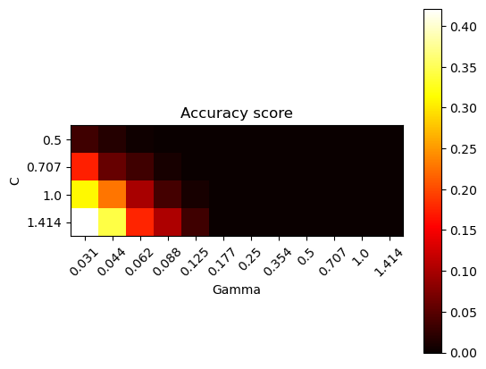

```python
scores = grid.cv_results_["mean_test_score"]
scores = np.array(scores).reshape(len(grid.param_grid["C"]), len(grid.param_grid["gamma"]))
fig, ax = plt.subplots(1,1, figsize = (6,5))
pt = ax.imshow(scores, interpolation='nearest', cmap=plt.cm.hot)
fig.colorbar(pt)
ax.set_xticks(np.arange(len(grid.param_grid['gamma'])),np.round(grid.param_grid['gamma'],3), rotation = 45)
ax.set_yticks(np.arange(len(grid.param_grid['C'])),np.round(grid.param_grid['C'],3))
ax.set_xlabel('Gamma')
ax.set_ylabel('C')
ax.set_title('Accuracy score')
```

Above, I perform a grid serach on the parameters of a support vector machine algorithm using an rbf kernel. A crude search provides a broad region over which we can further fine tune the parameters, which I do below.

Performing a fine tune search on the parameters of the rbf kernel.

```python
nlsvm = SVC(random_state= 0)
parameters = {'gamma': list(np.arange(0.005, 0.105, 0.01)), 'C': list(np.arange(0.5, 7, 0.45))}
grid_accuracy = GridSearchCV(nlsvm, param_grid= parameters, cv = 3).fit(X_train, y_train)
scores_accuracy = grid_accuracy.cv_results_["mean_test_score"]
scores_accuracy = np.array(scores_accuracy).reshape(len(grid_accuracy.param_grid["C"]), len(grid_accuracy.param_grid["gamma"]))
```

Because of the conditions mentioned above, recall, precision, and f1 scores are more important to us, we will below perfrom grid search to report these scores on using the grid search. Although the plots below show the grid search over a concetrated region, showing clearly a region of optimal scores, I had to initially do more searches to narrow dow the region of optimL values. To keep the notebook clean and interprettable, I have not shown some of the crude search results that I did to drill down to a narrow region of optimal values.

Performing computations for the recall score.

```python
nlsvm = SVC(random_state= 0)
parameters = {'gamma': list(np.arange(0.005, 0.035, 0.005)), 'C': list(np.arange(2, 11, 0.25))}
grid_recall = GridSearchCV(nlsvm, param_grid= parameters, cv = 3, scoring = 'recall').fit(X_train, y_train)
scores_recall = grid_recall.cv_results_["mean_test_score"]
scores_recall = np.array(scores_recall).reshape(len(grid_recall.param_grid["C"]), len(grid_recall.param_grid["gamma"]))
```

Performing computations for the precision score.

```python
nlsvm = SVC(random_state = 0)
parameters_precision = {'gamma': list(np.arange(0.005, 0.095, 0.01)), 'C': list(np.arange(1, 8, 0.5))}
grid_precision = GridSearchCV(nlsvm, param_grid= parameters_precision, cv = 3, scoring = 'precision').fit(X_train, y_train)
scores_precision = grid_precision.cv_results_["mean_test_score"]
scores_precision = np.array(scores_precision).reshape(len(grid_precision.param_grid["C"]), len(grid_precision.param_grid["gamma"]))
```

Performing computations for F1 score.

```python
nlsvm = SVC(random_state = 0)
parameters_f1 = {'gamma': list(np.arange(0.005, 0.095, 0.01)), 'C': list(np.arange(1, 8, 0.5))}
grid_f1 = GridSearchCV(nlsvm, param_grid= parameters_f1, cv = 3, scoring = 'f1').fit(X_train, y_train)
scores_f1 = grid_f1.cv_results_["mean_test_score"]
scores_f1 = np.array(scores_f1).reshape(len(grid_f1.param_grid["C"]), len(grid_f1.param_grid["gamma"]))
```

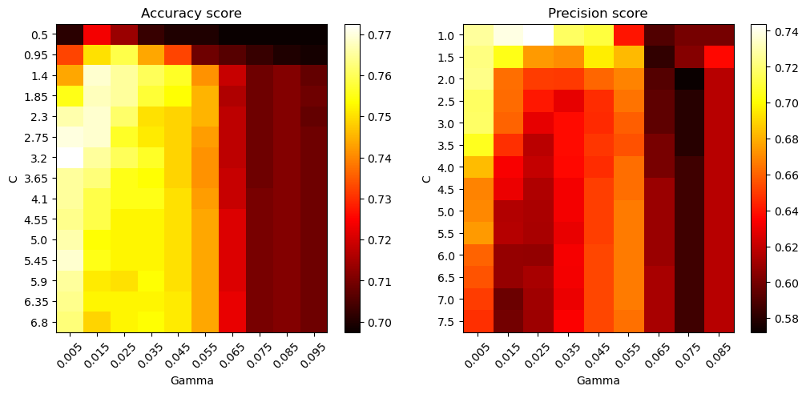

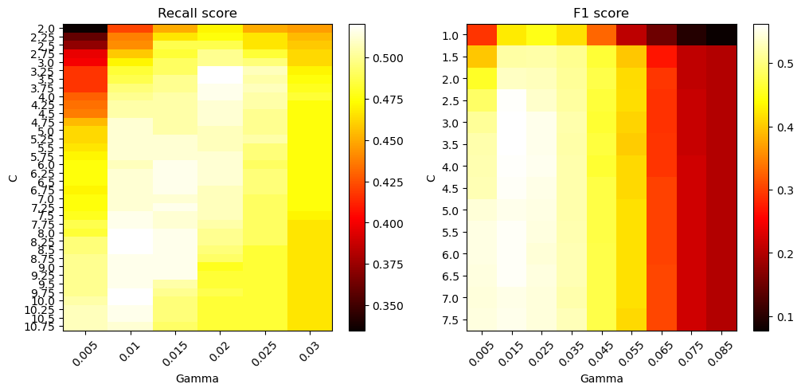

```python
fig, ax = plt.subplots(1,2, figsize = (12,5))
im_accuracy = ax[0].imshow(scores_accuracy, interpolation='nearest', cmap=plt.cm.hot, aspect = 'auto')
fig.colorbar(im_accuracy)
ax[0].set_xticks(np.arange(len(grid_accuracy.param_grid['gamma'])),np.round(grid_accuracy.param_grid['gamma'],3), rotation = 45)
ax[0].set_yticks(np.arange(len(grid_accuracy.param_grid['C'])),np.round(grid_accuracy.param_grid['C'],3))
ax[0].set_xlabel('Gamma')
ax[0].set_ylabel('C')
ax[0].set_title('Accuracy score')

im_precision = ax[1].imshow(scores_precision, interpolation='nearest', cmap=plt.cm.hot, aspect = 'auto')
fig.colorbar(im_precision)
ax[1].set_xticks(np.arange(len(grid_precision.param_grid['gamma'])),np.round(grid_precision.param_grid['gamma'],3), rotation = 45)
ax[1].set_yticks(np.arange(len(grid_precision.param_grid['C'])),np.round(grid_precision.param_grid['C'],3))
ax[1].set_xlabel('Gamma')
ax[1].set_ylabel('C')
ax[1].set_title('Precision score')

fig, ax = plt.subplots(1,2, figsize = (12,5))
im_recall = ax[0].imshow(scores_recall, interpolation='nearest', cmap=plt.cm.hot, aspect = 'auto')
fig.colorbar(im_recall)
ax[0].set_xticks(np.arange(len(grid_recall.param_grid['gamma'])),np.round(grid_recall.param_grid['gamma'],3), rotation = 45)
ax[0].set_yticks(np.arange(len(grid_recall.param_grid['C'])),np.round(grid_recall.param_grid['C'],3))
ax[0].set_xlabel('Gamma')
ax[0].set_ylabel('C')
ax[0].set_title('Recall score')

im_f1 = ax[1].imshow(scores_f1, interpolation='nearest', cmap=plt.cm.hot, aspect = 'auto')
fig.colorbar(im_f1)
ax[1].set_xticks(np.arange(len(grid_f1.param_grid['gamma'])),np.round(grid_f1.param_grid['gamma'],3), rotation = 45)
ax[1].set_yticks(np.arange(len(grid_f1.param_grid['C'])),np.round(grid_f1.param_grid['C'],3))
ax[1].set_xlabel('Gamma')
ax[1].set_ylabel('C')
ax[1].set_title('F1 score')
```

Note: All the above subplots have different scales, i.e., the same color on each of these plots have different values. Since each of these plots have significantly different range of values, defining a colormap over a single range didn't work well. So, I left each subplot with its own colorbar, as shown on the right of each of the subplots.  
It appears from the plots that each of the metrics have its own set of optimal parameters. Considering accuracy remains high over a broad range, we can choose parameters that optimizes either recall or f1 score. Below are the parameters that best optimizes the f1 score during the grid serach and the metrics calculated using the best model on the test dataset. Here, we do not compute the precision-recall curve, as its calculations significantly increased the cost-computation.

```python
print('Best parameters: ', grid_f1.best_params_)
# computing the scores on the test data using the best estimator
clf = grid_f1.best_estimator_
y_pred = clf.predict(X_test)
display('Accuracy: '+ str(round(accuracy_score(y_test, y_pred), 3)))
display('Precision: '+ str(round(precision_score(y_test, y_pred), 3)))
display('Recall: '+ str(round(recall_score(y_test, y_pred), 3)))
display('F1 score: '+ str(round(f1_score(y_test, y_pred), 3)))
```

```
Best parameters:  {'C': 3.5, 'gamma': 0.015}
```

```
'Accuracy: 0.735'
```

```
'Precision: 0.551'
```

```
'Recall: 0.466'
```

```
'F1 score: 0.505'
```

## Conclusion

Below, I provide a table listing the scores on the test dataset from all the classifiers we analyzed in this notebook.

| Classifier | Accuracy | Precison | Recall | F1 score | AUC |
| --- | --- | --- | --- | --- | --- |
| Logistic Classification using 'lbfgs' solver | 0.705 | 0.494 | 0.672 | 0.569 | 0.527 |
| K-Nearest Neighbors | 0.695 | 0.471 | 0.414 | 0.44 | 0.479 |
| Decision Tree Classifier with pruning | 0.75 | 0.58 | 0.5 | 0.537 | 0.502 |
| Random Forest | 0.77 | 0.658 | 0.431 | 0.521 | 0.563 |
| Ada Boost | 0.74 | 0.548 | 0.586 | 0.567 | 0.49 |
| Gradient Boosting | 0.785 | 0.66 | 0.534 | 0.59 | 0.653 |
| SVM - linear Kernel | 0.73 | 0.538 | 0.483 | 0.509 | 0.482 |
| SVM - rbf Kernel | 0.735 | 0.551 | 0.466 | 0.505 | Computationally expensive |